# Assignment 3 Task 2

Sarah Lam

11/4/2021

### 1. Overview and Introduction

This report provides an exploratory overview of differences in weights for juvenile snowshoe hares observed at the Bonanza Creek Long Term Ecological Research (LTER) network site from 1999 - 2012 (Kielland, et al. 2017). Specifically, weights are compared between male and female juvenile hares, and the relationship between weight and hind foot length explored. Snowshoe hares, a keystone prey species in the boreal forests of Alaska, have populations that go through fluctuations of about 8-11 years, impacting vegetation density and predator populations in respsonse to this population flux.

### 2. Data and analyses

Snowshoe hare structural size measurements were collected and made available by Dr. Knut Kielland and colleagues at the Bonanza Creek Long Term Ecological Research (LTER) network site in Alaska. The data contain observations for 3197 unique snowshoe hares, collected over fourteen years (1999 - 2012). Following exploratory data visualization, weights between male and female hares are analyzed by two-sample t-tests using a significance level (α) of 0.05 throughout. Differences between groups are described by Cohen’s d effect size. The relationship between hind foot length and weight is explored by simple linear regression. All analyses are in R version 4.1.1 using RStudio version 1.4.1717.

### 3. Juvenile hare initial investigation

#### a. Annual juvenile hare trap counts

The total number of juvenile hare trappings during each year of the study.

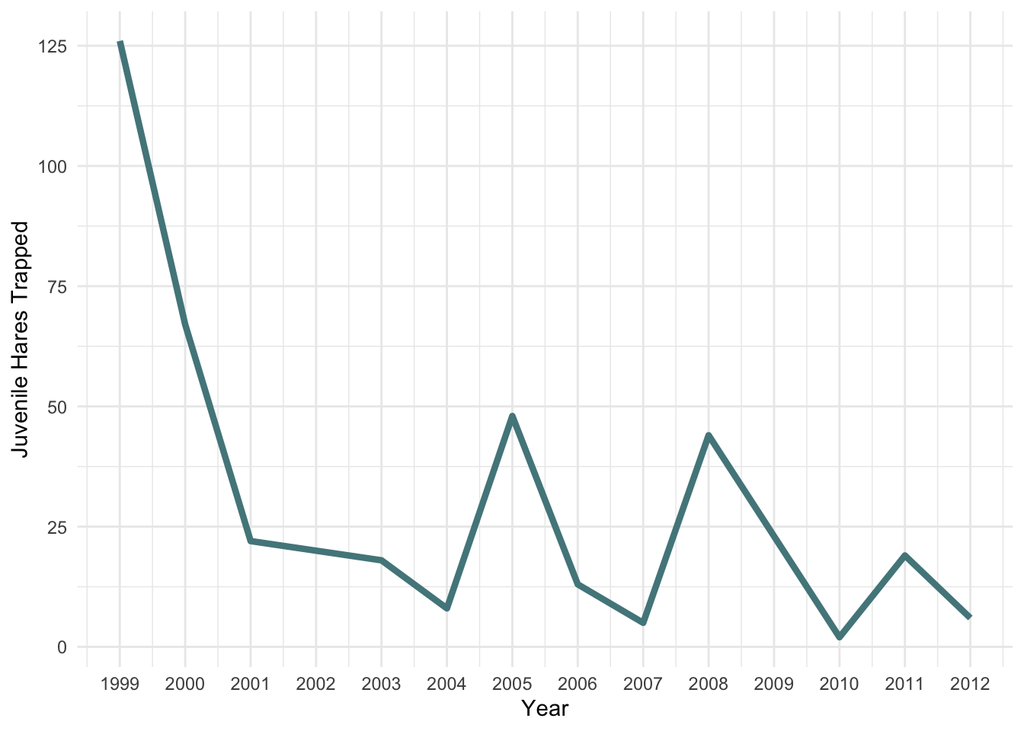

**Fig. 1** Line graph of annual trap counts of juvenile snowshoe hares.

In the above graph of total snowshoe hare trappings we can see that the year to year trappings have overall decreased from 1999 to 2012. The maximum trap count is 126 hares trapped which was in 1999 and the minimum trap count is 2 hares trapped which was in 2010. The average number of trappings is 31.5 hares trapped. This decrease in hares trapped may not be reflective of the hare populations as additional factors that influence this count includes effort. To standardize the juvenile hare population in future analyses we could potentially standardize trapping methods such as time of year, temperature on day of trapping, and time of day of trapping.

#### b. Juvenile hare weight comparison and descriptive statistics

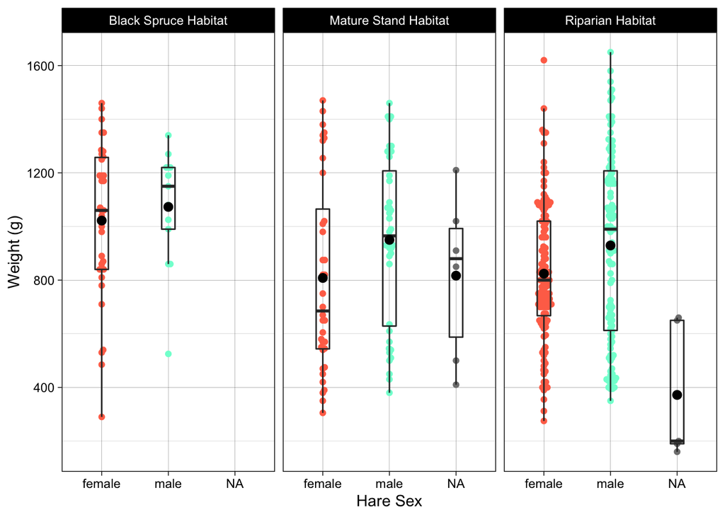

**Fig. 2.** Weight observations for juvenile snowshoe hares across three sample trapping sites. Coral (female) and teal (male) points indicate individual observations for weight (grams) of a juvenile snowshoe hare. Box endpoints indicate the 25<sup>th</sup> and 75<sup>th</sup> percentile values; the black line and black point within the box indicate the median and mean value for each species, respectively. Data: Kielland et al. (2017).

The weights (all in grams) for female and male juvenile snowshoe hares were compared across the three trapping sites, a black spruce forest, a forest consisting of various mature stands of tree species, and a riparian flood zone. Male juvenile snowshoe hares are on average larger than female hares at each site.

**Table 1.** Descriptive statistics (mean, median, standard deviation, and sample size) for male and female juvenile snowshoe hares. Data: Kielland et al. (2017).

[output not shown]

On average, male juvenile snowshoe hares are larger than juvenile female snowshoe hares (945.86 $\pm$ 333.22 and 855.39 $\pm$ 292.25 g, respectively; mean $\pm$ 1 standard deviation). The absolute difference in means is 90.47 g (a 10.05% difference). This difference in means may be significant (Welch’s two-sample t-test: t(325.02) = 2.71, p = 0.007), however the effect size is small (Cohen’s *d* = 0.29).

#### c. Relationship between juvenile hare weight and hindfoot length

As a starting point, the relationship between weight and hind foot length was explored for male and female hares; further analysis is needed to compare the relationship between hind foot and weight among juvenile hares.

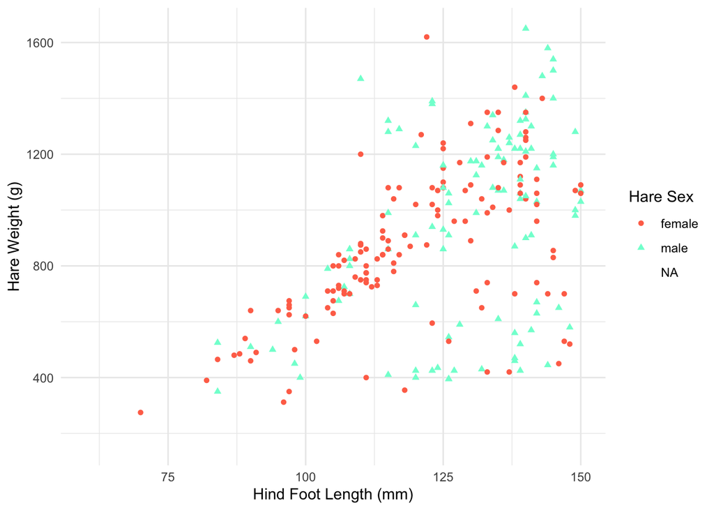

**Fig. 3** Relationship between hind foot length (mm) and weight (g) for the juvenile snowshoe hares. Points indicate individual hare measurements (female = coral circles; male = teal triangles). Data: Kielland et al. (2017).

The relationship between hind foot length and weight appears somewhat linear, (Figure 3). Simple linear regression reveals that hind foot length may significantly predict weight, but only 30% of variance in weight is explained by hind foot length (p < 0.001, R<sup>2</sup> = 0.3). The regression has an average slope of $\beta$ = 9.52 g mm<sup>-1</sup> (i.e., for each one millimeter increase in hindfoot length we expect an average increase in body mass of 9.52 g). Therefore, hind foot length and weight are weakly, but significantly, positively correlated (Pearson’s *r* = 0.55, p < 0.001). Diagnostic plots (not included) suggest fairly normally distributed residuals, plus the central limit theorem holds for a sample size this large which means the the means should be normally distributed. However, the diagnostic plots also reveal that the residuals are not homoscedastic. This is concerning because homoscedasticity is one of the four main assumptions of a simple linear regression.

**Fig. 4** Model summary for simple linear regression of the relationship between hare weight (g) and hind foot length (hindft, mm).

|  | *Dependent variable:* |
| --- | --- |
|  | weight |
| hindft | 9.523*** |
|  | (0.928) |
| Constant | -279.342** |
|  | (115.481) |
| Observations | 249 |
| R<sup>2</sup> | 0.299 |
| Adjusted R<sup>2</sup> | 0.296 |
| Residual Std. Error | 263.888 (df = 247) |
| F Statistic | 105.238*** (df = 1; 247) |
| *Note:* | p<0.1; p<0.05; p<0.01 |

### Summary

Exploratory data analysis reveals the following initial findings:

- Male juvenile snowshoe hares are on average larger than female juvenile snowshoe hares
- Hind foot length and weight are loosely positively correlated in juvenile snowshoe hares

Next steps:

- Compare weights statistically (one-way ANOVA), including penguin sample site as a covariate
- Sample counts broken down by site
- Analysis of sampling sites to explore size correlation and habitat

### Citations

Hlavac, Marek (2018). stargazer: Well-Formatted Regression and Summary Statistics Tables. R package version 5.2.2. https://CRAN.R-project.org/package=stargazer

Kielland, K., F.S. Chapin, R.W. Ruess, and Bonanza Creek LTER. 2017. Snowshoe hare physical data in Bonanza Creek Experimental Forest: 1999-Present ver 22. Environmental Data Initiative. https://doi.org/10.6073/pasta/03dce4856d79b91557d8e6ce2cbcdc14